# TP5: Decision trees & random forests

The aim of this tutorial is to get familiar with the use of decision trees and their generalizations on simple examples using `scikit-learn` tools.

## Completing your installation first

You will need to install packages `python-graphviz` first. If needed, uncomment the `conda` command below:

```python
# If needed, uncomment the line below:

# !pip install graphviz
```

```python
from pylab import *
import numpy as np
import matplotlib.pyplot as plt
import seaborn as sns
import os
os.environ["PATH"] += os.pathsep + 'D:/Program Files (x86)/Graphviz2.38/bin/'
# Load the library with the iris dataset
from sklearn.datasets import load_iris, load_wine



# Load scikit's decision tree classifier
from sklearn import tree

# Load scikit's random forest classifier library
from sklearn.ensemble import RandomForestClassifier, RandomForestRegressor

# To visualize trees
import graphviz


# Load pandas to manipulate data frames (Excel like)
import pandas as pd

# Load numpy
#import numpy as np
from sklearn.metrics import (
    precision_score,
    recall_score,
    f1_score,
    confusion_matrix,
    matthews_corrcoef,
    ConfusionMatrixDisplay,
    accuracy_score,
    plot_confusion_matrix
)
# Set random seed
np.random.seed(0)
```

The data for this tutorial is famous. Called, **the iris dataset**, it contains four variables measuring various parts of iris flowers of three related species, and then a fourth variable with the species name. The reason it is so famous in machine learning and statistics communities is because the data requires very little preprocessing (i.e. no missing values, all features are floating numbers, etc.).

```python
iris = load_iris()
```

## Step 1: explore the data set

1. What is the structure of the object `iris` ?
2. Plot this dataset in a well chosen set of representations to explore the data.
1. iris is similar to a dictionary (a DataFrame), it has the attribute data = matrix of features, target: the column (or matrix) of target values, target anmes and feature names. It could be a tuple if the parameter return_Xy in load_iris() is set to True.
1. We can plot the dataset 1 feature vs 1 and separate the classes, this can give us an overview of the data distribution and the possiblity to create a hierarchical decision boundary.

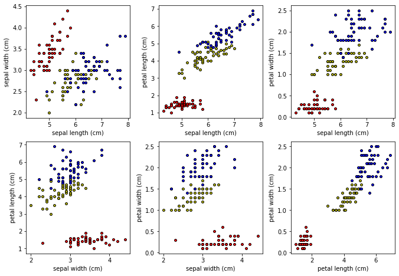

```python
df = pd.DataFrame(iris.data, columns=iris.feature_names)
df['species'] = pd.Categorical.from_codes(iris.target, iris.target_names)
plt.figure(figsize=(10, 7), facecolor="white")
for indices, attributs in enumerate([[0, 1], [0, 2], [0, 3], [1, 2], [1, 3], [2, 3]]):

    col1 = iris.feature_names[attributs[0]]
    col2 = iris.feature_names[attributs[1]]

    X = df.iloc[:, attributs]
    X = np.array(X)
    ax = plt.subplot(2, 3, indices + 1)
    plt.tight_layout(h_pad=0.5, w_pad=0.5, pad=2.5)

    for i, color in zip(['setosa', 'versicolor', 'virginica'], "ryb"):
        idx = np.where(df['species'] == i)
        plt.scatter(X[idx, 0],X[idx, 1],c=color,label=i,cmap=plt.cm.RdYlBu,edgecolor="black",s=15)
    plt.xlabel(col1)
    plt.ylabel(col2)
```

Based on the figures above, using sepal features might not work for a decision tree as it would be difficult to create a hierarchical boundary. On the other hand, petal features (and sepal width vs petal width) seem to be organized in a way that a decision tree wouldn't have a difficulty separating the classes.

## Using `pandas` to manipulate the data

Pandas is great to manipulate data in a Microsoft Excel like way.

```python
import pandas as pd

# Create a dataframe with the four feature variables
df = pd.DataFrame(iris.data, columns=iris.feature_names)

# View the top 5 rows
df.head()
```

|  | sepal length (cm) | sepal width (cm) | petal length (cm) | petal width (cm) |
| --- | --- | --- | --- | --- |
| 0 | 5.1 | 3.5 | 1.4 | 0.2 |
| 1 | 4.9 | 3.0 | 1.4 | 0.2 |
| 2 | 4.7 | 3.2 | 1.3 | 0.2 |
| 3 | 4.6 | 3.1 | 1.5 | 0.2 |
| 4 | 5.0 | 3.6 | 1.4 | 0.2 |

```python
# Add a new column with the species names, this is what we are going to try to predict
df['species'] = pd.Categorical.from_codes(iris.target, iris.target_names)

# View the top 5 rows
df.head()
```

|  | sepal length (cm) | sepal width (cm) | petal length (cm) | petal width (cm) | species |
| --- | --- | --- | --- | --- | --- |
| 0 | 5.1 | 3.5 | 1.4 | 0.2 | setosa |
| 1 | 4.9 | 3.0 | 1.4 | 0.2 | setosa |
| 2 | 4.7 | 3.2 | 1.3 | 0.2 | setosa |
| 3 | 4.6 | 3.1 | 1.5 | 0.2 | setosa |
| 4 | 5.0 | 3.6 | 1.4 | 0.2 | setosa |

```python
df.describe() # get a summary of the datarfame
```

|  | sepal length (cm) | sepal width (cm) | petal length (cm) | petal width (cm) |
| --- | --- | --- | --- | --- |
| count | 150.000000 | 150.000000 | 150.000000 | 150.000000 |
| mean | 5.843333 | 3.057333 | 3.758000 | 1.199333 |
| std | 0.828066 | 0.435866 | 1.765298 | 0.762238 |
| min | 4.300000 | 2.000000 | 1.000000 | 0.100000 |
| 25% | 5.100000 | 2.800000 | 1.600000 | 0.300000 |
| 50% | 5.800000 | 3.000000 | 4.350000 | 1.300000 |
| 75% | 6.400000 | 3.300000 | 5.100000 | 1.800000 |
| max | 7.900000 | 4.400000 | 6.900000 | 2.500000 |

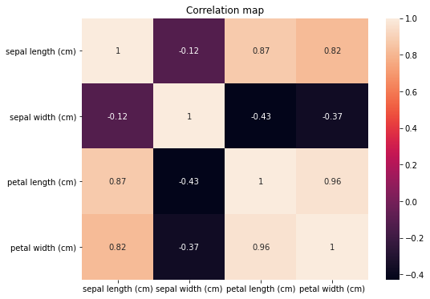

```python
corr_df = df.corr(method='pearson')

plt.figure(figsize=(8, 6), facecolor="white")
sns.heatmap(corr_df, annot=True)
plt.title("Correlation map")
plt.show()
```

All features are correlated except for the sepal width. Based on the plot in the first step, we could have concluded that excluding sepal feature would be beneficial to the model in terms of complexity and performance (a model more decisive on the rest of the features). However, we usually want features that are not all correlated with each other , since it might create a certain redundancy, so we will keep the sepal features (or at least keep sepal width).

## Step 2: create training and test sets

Create a new column that for each row, generates a random number between 0 and 1, and if that value is less than or equal to .75, then sets the value of that cell as True and false otherwise. This is a quick and dirty way of randomly assigning some rows to be used as the training data and some as the test data.

```python
df['is_train'] = np.random.uniform(0, 1, len(df)) <= .75

# View the top 5 rows
df.head()
```

|  | sepal length (cm) | sepal width (cm) | petal length (cm) | petal width (cm) | species | is_train |
| --- | --- | --- | --- | --- | --- | --- |
| 0 | 5.1 | 3.5 | 1.4 | 0.2 | setosa | True |
| 1 | 4.9 | 3.0 | 1.4 | 0.2 | setosa | True |
| 2 | 4.7 | 3.2 | 1.3 | 0.2 | setosa | True |
| 3 | 4.6 | 3.1 | 1.5 | 0.2 | setosa | True |
| 4 | 5.0 | 3.6 | 1.4 | 0.2 | setosa | True |

```python
# Create two new dataframes, one with the training rows, one with the test rows
train, test = df[df['is_train']==True], df[df['is_train']==False]
```

```python
# Show the number of observations for the test and training dataframes
print('Number of observations in the training data:', len(train), f', it represents {round(len(train)/df.shape[0]*100, 2)}% of data')
print('Number of observations in the test data:',len(test), f', it represents {round(len(test)/df.shape[0]*100, 2)}% of data')
```

```
Number of observations in the training data: 118 , it represents 78.67% of data
Number of observations in the test data: 32 , it represents 21.33% of data
```

```python
# Create a list of the feature column's names
features = df.columns[:4]

# View features
features
```

```
Index(['sepal length (cm)', 'sepal width (cm)', 'petal length (cm)',
       'petal width (cm)'],
      dtype='object')
```

```python
# train['species'] contains the actual species names. Before we can use it,
# we need to convert each species name into a digit. So, in this case there
# are three species, which have been coded as 0, 1, or 2.
y = pd.factorize(train['species'])[0]
y_test = pd.factorize(test['species'])[0]
```

## Step 3: decision trees for the iris dataset

The method `tree.DecisionTreeClassifier()` from `scikit-learn` builds decision trees objects as follows:

```python
clf = tree.DecisionTreeClassifier()
clf_t = clf.fit(train[features], y)
y_pred = clf.predict(test[features])

# Using the whole dataset you may use directly:
#clf = clf.fit(iris.data, iris.target)
```

```python
# Model Accuracy, how often is the classifier correct?

print("Accuracy:", accuracy_score(y_test, y_pred))
```

```
Accuracy: 0.9375
```

The `export_graphviz` exporter supports a variety of aesthetic options, including coloring nodes by their class (or value for regression) and using explicit variable and class names if desired. Jupyter notebooks also render these plots inline automatically:

```python
os.environ["PATH"] += os.pathsep + 'C:/Program Files (x86)/Graphviz2.38/bin/'
dot_data = tree.export_graphviz(clf_t, out_file=None,
                         feature_names=iris.feature_names,
                         class_names=iris.target_names,
                         filled=True, rounded=True,
                         special_characters=True)
graph = graphviz.Source(dot_data)
graph
```

[figure not shown]

We can also export the tree in Graphviz format and savethe resulting graph in an output file iris.pdf:

```python
dot_data = tree.export_graphviz(clf, out_file=None)
graph = graphviz.Source(dot_data)
graph.render("iris")
```

```
'iris.pdf'
```

After being fitted, **the model can then be used to predict the class of samples**:

```python
class_pred = clf.predict(iris.data[:1, :])
class_pred
```

```
array([0], dtype=int64)
```

We create a diagnostic functions to get the scores and plot confusion matrices for multiple (3) models:

```python
def print_diagnostics(diags):
    print("\n")
    print("Precision: %1.3f" % diags[0])
    print("Recall: %1.3f" % diags[1])
    print("F1 score: %1.3f" % diags[2])
    print("MCC score: %1.3f" % diags[4])
    print("Accuracy: %1.3f" % diags[5])

    # plt.show()

def get_diagnostics(y_pred, y_valid, model_name,  print=False):
    """returns all evaluation metrics"""

    diags = (
        precision_score(y_valid, y_pred, average="macro"),
        recall_score(y_valid, y_pred, average="macro"),
        f1_score(y_valid, y_pred, average="macro"),
        matthews_corrcoef(y_valid, y_pred),
        accuracy_score(y_valid, y_pred),
    )
    if print:
        print_diagnostics(diags)
    return {"model": model_name, "precision": diags[0], "recall": diags[1], "F1-score": diags[2], "MCC": diags[3], "Accuracy": diags[4]}
def compare(y_test, y_pred1, y_pred2, y_pred3, experiment):
    """plot side to side three confusion matrices for three models"""

    fig, ax = plt.subplots(1,3, figsize=(20,5), facecolor="white")
    ax[0].set_title("sepal features")
    ax[1].set_title("petal features")
    ax[2].set_title("all features")
    fig.suptitle(experiment, fontsize=14)

    ConfusionMatrixDisplay(
    confusion_matrix = confusion_matrix(y_test, y_pred1),
    display_labels = iris.target_names).plot(ax=ax[0], colorbar=False)

    ConfusionMatrixDisplay(
    confusion_matrix = confusion_matrix(y_test, y_pred2),
    display_labels = iris.target_names).plot(ax=ax[1], colorbar=False)

    ConfusionMatrixDisplay(
    confusion_matrix = confusion_matrix(y_test, y_pred3),
    display_labels = iris.target_names).plot(ax=ax[2], colorbar=False)
```

## Exercise 1

1. Train the decision tree on the iris dataset and explain how one should read blocks in `graphviz` representation of the tree.
2. Plot the regions of decision with the points of the training set superimposed.

*Indication: you may find the function `plt.contourf` useful.

```python
df['is_train'] = np.random.uniform(0, 1, len(df)) <= .75

# Create two new dataframes, one with the training rows, one with the test rows
train, test = df[df['is_train']==True], df[df['is_train']==False]

y_train = pd.factorize(train['species'])[0]
y_test = pd.factorize(test['species'])[0]

features = df.columns[:4]
```

```python
clf = tree.DecisionTreeClassifier() # with default values
clf = clf.fit(train[features], y_train)
```

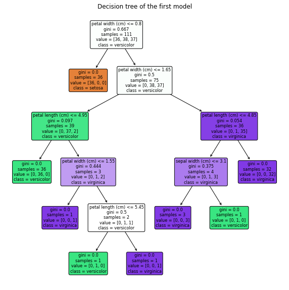

```python
plt.figure(figsize=(10, 10), facecolor="white")
plt.subplot(1, 1, 1)
tree.plot_tree(clf,
                feature_names=iris.feature_names,
                class_names=iris.target_names,
                filled=True, rounded=True)
plt.title("Decision tree of the first model")
plt.show()
```

In the decision tree chart, each internal node has a decision rule that splits the data. Gini referred as Gini ratio, which measures the impurity of the node.

You can say a node is pure when all of its records belong to the same class, such nodes known as the leaf node. Here, the resultant tree is not pruned by default.

#### Performance on test set check

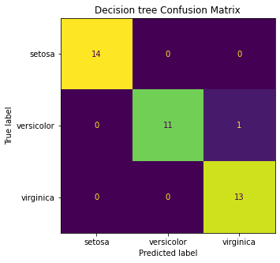

```python
y_pred = clf.predict(test[features])
fig, ax = plt.subplots(1,1, figsize=(20,5), facecolor="white")
ConfusionMatrixDisplay(
    confusion_matrix = confusion_matrix(y_test, y_pred),
    display_labels = iris.target_names).plot(ax=ax, colorbar=False)

plt.title("Decision tree Confusion Matrix")
plt.show()
```

The setosa can be easily distinguished from the other two classes even on the test set, versicolor still creates some confusion to the model as it can classified as virginica (class 3).

We can also plot the decision boundary of the tree on two features. Based on the documentation of sklearn, we train a tree with the same configurations as ours, but on pairs of features and then plot the decision on the grid generated by the two axis:

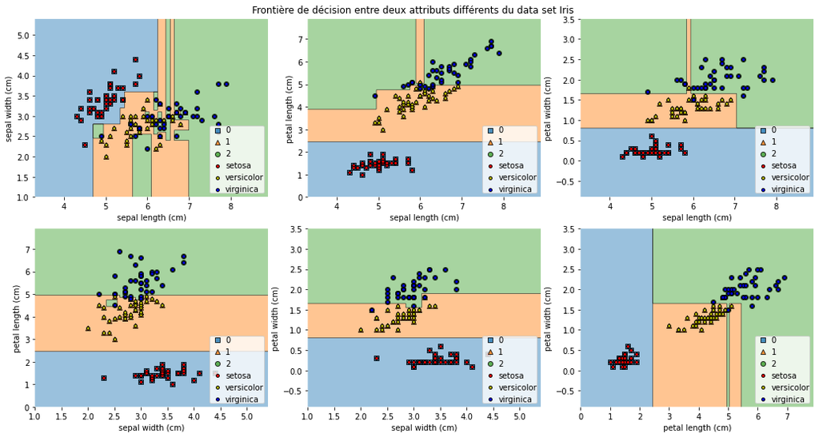

```python
import warnings
from mlxtend.plotting import plot_decision_regions
warnings.filterwarnings("ignore")
plt.figure(figsize=(15, 8), facecolor="white")

for indices, attributs in enumerate([[0, 1], [0, 2], [0, 3], [1, 2], [1, 3], [2, 3]]):
    col1 = iris.feature_names[attributs[0]]
    col2 = iris.feature_names[attributs[1]]
    X = train.iloc[:, attributs]

    clf = tree.DecisionTreeClassifier().fit(X, y_train)

    X = np.array(X)
    ax = plt.subplot(2, 3, indices + 1)
    plt.tight_layout(h_pad=0.5, w_pad=0.5, pad=2.5)
    plot_decision_regions(X, y_train, clf=clf, legend=0)

    for i, color in zip(range(3), "ryb"):
        idx = np.where(y_train == i)
        plt.scatter(X[idx, 0], X[idx, 1], c=color, label=train['species'].unique()[i], cmap=plt.cm.RdYlBu,edgecolor="black", s=15)
    plt.xlabel(col1)
    plt.ylabel(col2)
    plt.legend(loc="lower right", borderpad=0, handletextpad=0)
plt.suptitle("Frontière de décision entre deux attributs différents du data set Iris")

plt.show()
```

The plot confirms the hypothesis we made in the first step. We have a lot of lines (regions) in the plot sepal width vs sepal length, which means that the tree is really deep and this is an indicator of a potential overfitting.

## Exercise 2

1. Build 2 different trees based on a sepal features (sepal lengths, sepal widths) vs petal features (petal lengths, petal widths) only: which features are the most discriminant?
2. Compare performances with those obtained using all features.
3. Try the same as above using the various splitting criterion available, Gini's index, classification error or cross-entropy. Comment on your results.

```python
df['is_train'] = np.random.uniform(0, 1, len(df)) <= .75

# Create two new dataframes, one with the training rows, one with the test rows
train, test = df[df['is_train']==True], df[df['is_train']==False]

y_train = pd.factorize(train['species'])[0]
y_test = pd.factorize(test['species'])[0]

features = df.columns[:4]
```

```python
df_results = pd.DataFrame({})
```

```python
clf3 = tree.DecisionTreeClassifier()
# train on all features
clf_total = clf3.fit(train[features], y_train)
test3 = test[features]
# prediction
pred3 = clf_total.predict(test3)
# add results to the dataframe
df_results = df_results.append(get_diagnostics(pred3, y_test, "DT with all features"), ignore_index=True)
```

Train a second model on only sepal features

```python
clf1 = tree.DecisionTreeClassifier()
# train on sepal features
clf_sepal = clf1.fit(train[[f for f in features if "sepal" in f]], y_train)
test1 = test[[f for f in features if "sepal" in f]]
pred1 = clf_sepal.predict(test1)
# add results to the dataframe
df_results = df_results.append(get_diagnostics(pred1, y_test, "DT with sepal features"), ignore_index=True)
```

Train a third model on only petal features

```python
clf2 = tree.DecisionTreeClassifier()
# train on petal features
test2 = test[[f for f in features if "petal" in f]]
clf_petal = clf2.fit(train[[f for f in features if "petal" in f]], y_train)
pred2 = clf_petal.predict(test2)
# add results to the dataframe
df_results = df_results.append(get_diagnostics(pred2, y_test, "DT with petal features"), ignore_index=True)
```

Get the performance metrics values on all models:

```python
df_results
```

|  | model | precision | recall | F1-score | MCC | Accuracy |
| --- | --- | --- | --- | --- | --- | --- |
| 0 | DT with all features | 0.944444 | 0.948718 | 0.941919 | 0.918922 | 0.942857 |
| 1 | DT with sepal features | 0.720280 | 0.710684 | 0.714445 | 0.570726 | 0.714286 |
| 2 | DT with petal features | 0.969697 | 0.974359 | 0.970794 | 0.958234 | 0.971429 |

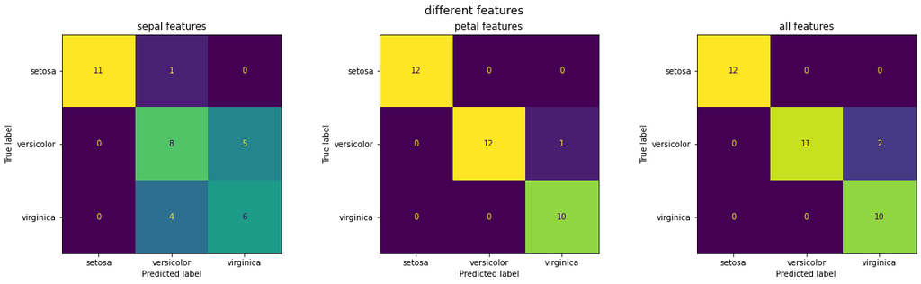

```python
compare(y_test, pred1, pred2, pred3, "different features")
```

In this configuration, the data set with only petal features performs the best. We could say that the sepal features don't add valuable information to the model or they create confusion. So to be sure, we will plot both trees (with only petal information, and only septal information):

[figure not shown]

```python
plt.figure(figsize=(20, 20), facecolor="white")
plt.subplot(2, 2, 1)
tree.plot_tree(clf_sepal,
                feature_names=iris.feature_names,
                class_names=iris.target_names,
                filled=True, rounded=True)
plt.title("Tree with only sepal features")
plt.subplot(2, 2, 2)
tree.plot_tree(clf_petal,
                feature_names=iris.feature_names,
                class_names=iris.target_names,
                filled=True, rounded=True)
plt.title("tree with only petal features")
plt.show()
```

From the first plots we could see that it would be much more difficult to create a hierachical diagramm with the sepal features than the petal features, which ultimately would make the model with all the features perform worse than the one with only petal features. We will change the min_samples_leaf for the sepal classifier to 10 (for a data to be statistically significant we should have $\sqrt{N}$ samples per class):

```python
clf1 = tree.DecisionTreeClassifier(min_samples_leaf=10) # specify minimum samples at leaf level
clf_sepal = clf1.fit(train[[f for f in features if "sepal" in f]], y_train)
test1 = test[[f for f in features if "sepal" in f]]
pred1 = clf_sepal.predict(test1)
# put results in the resultat dataframe
df_results = df_results.append(get_diagnostics(pred1, y_test, "DT with sepal features 10 samples "), ignore_index=True)
# get relevant results for this experiment:
df_results.loc[df_results["model"].isin(["DT with sepal features","DT with sepal features 10 samples "])]
```

[output not shown]

This modification was not able to improve the results, the performance on all the features didn't improve either when limiting the minimum samples leaf to 10:

```python
clf3 = tree.DecisionTreeClassifier(min_samples_leaf=10)
```

```python
clf_total = clf3.fit(train[features], y_train)
test3 = test[features]
pred3 = clf_total.predict(test3)
# put results in the resultat dataframe
df_results = df_results.append(get_diagnostics(pred3, y_test, "DT with all features 10 samples "), ignore_index=True)
# get relevant results for this experiment:
df_results.loc[df_results["model"].isin(["DT with all features","DT with all features 10 samples "])]
```

|  | model | precision | recall | F1-score | MCC | Accuracy |
| --- | --- | --- | --- | --- | --- | --- |
| 0 | DT with all features | 0.944444 | 0.948718 | 0.941919 | 0.918922 | 0.942857 |
| 3 | DT with all features 10 samples | 0.941026 | 0.941026 | 0.941026 | 0.913793 | 0.942857 |

### Different splitting criterion

Since by default gini is used in sklearn decision trees, we will test the entropy and the log loss splitting criterions

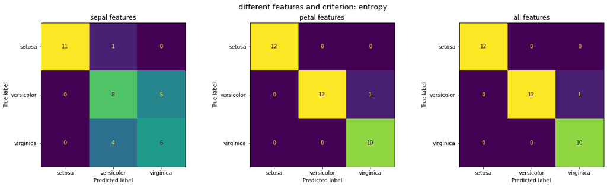

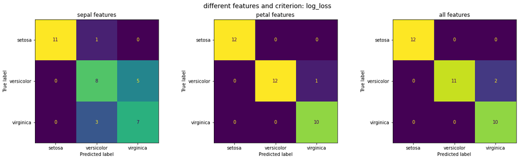

```python
for crit in ["entropy", "log_loss"]:
    # third classifier with all the features
    clf3 = tree.DecisionTreeClassifier(criterion=crit)
    clf_total = clf3.fit(train[features], y_train)
    test3 = test[features]
    pred3 = clf_total.predict(test3)
    df_results = df_results.append(get_diagnostics(pred3, y_test, crit +" DT with all features"), ignore_index=True)
    compare(y_test, pred1, pred2, pred3, f"different features and criterion: {crit}")

    # first classifier with sepal features
    clf1 = tree.DecisionTreeClassifier(criterion=crit)
    clf_sepal = clf1.fit(train[[f for f in features if "sepal" in f]], y_train)
    test1 = test[[f for f in features if "sepal" in f]]
    pred1 = clf_sepal.predict(test1)
    df_results = df_results.append(get_diagnostics(pred1, y_test, crit+ " DT with sepal features"), ignore_index=True)

    # second classifier with petal features
    clf2 = tree.DecisionTreeClassifier(criterion= crit)
    test2 = test[[f for f in features if "petal" in f]]
    clf_petal = clf2.fit(train[[f for f in features if "petal" in f]], y_train)
    pred2 = clf_petal.predict(test2)
    df_results = df_results.append(get_diagnostics(pred2, y_test, crit + " DT with petal features"), ignore_index=True)
```

the dataframe containing the results: We mainly focus on the Accuracy, F1 score and MCC for model comparison as the F1 score summarizes the recall and precision (geometrical average)

```python
df_results
```

|  | model | precision | recall | F1-score | MCC | Accuracy |
| --- | --- | --- | --- | --- | --- | --- |
| 0 | DT with all features | 0.944444 | 0.948718 | 0.941919 | 0.918922 | 0.942857 |
| 1 | DT with sepal features | 0.720280 | 0.710684 | 0.714445 | 0.570726 | 0.714286 |
| 2 | DT with petal features | 0.969697 | 0.974359 | 0.970794 | 0.958234 | 0.971429 |
| 3 | DT with all features 10 samples | 0.941026 | 0.941026 | 0.941026 | 0.913793 | 0.942857 |
| 4 | entropy DT with all features | 0.969697 | 0.974359 | 0.970794 | 0.958234 | 0.971429 |
| 5 | entropy DT with sepal features | 0.750000 | 0.744017 | 0.744295 | 0.616709 | 0.742857 |
| 6 | entropy DT with petal features | 0.969697 | 0.974359 | 0.970794 | 0.958234 | 0.971429 |
| 7 | log_loss DT with all features | 0.944444 | 0.948718 | 0.941919 | 0.918922 | 0.942857 |
| 8 | log_loss DT with sepal features | 0.750000 | 0.744017 | 0.744295 | 0.616709 | 0.742857 |
| 9 | log_loss DT with petal features | 0.969697 | 0.974359 | 0.970794 | 0.958234 | 0.971429 |

### Going further ahead (not mandatory)

Try the same approach adapted to another toy dataset from `scikit-learn` described at: http://scikit-learn.org/stable/datasets/index.html

Play with another dataset available at: http://archive.ics.uci.edu/ml/datasets.html

We will implement a regression decision tree on the diabetes dataset:

```python
from sklearn.datasets import load_diabetes
diabetes = load_diabetes(as_frame=True)

df = pd.DataFrame(diabetes.data)
df["target"] = diabetes.target
df.head()
```

|  | age | sex | bmi | bp | s1 | s2 | s3 | s4 | s5 | s6 | target |
| --- | --- | --- | --- | --- | --- | --- | --- | --- | --- | --- | --- |
| 0 | 0.038076 | 0.050680 | 0.061696 | 0.021872 | -0.044223 | -0.034821 | -0.043401 | -0.002592 | 0.019907 | -0.017646 | 151.0 |
| 1 | -0.001882 | -0.044642 | -0.051474 | -0.026328 | -0.008449 | -0.019163 | 0.074412 | -0.039493 | -0.068332 | -0.092204 | 75.0 |
| 2 | 0.085299 | 0.050680 | 0.044451 | -0.005670 | -0.045599 | -0.034194 | -0.032356 | -0.002592 | 0.002861 | -0.025930 | 141.0 |
| 3 | -0.089063 | -0.044642 | -0.011595 | -0.036656 | 0.012191 | 0.024991 | -0.036038 | 0.034309 | 0.022688 | -0.009362 | 206.0 |
| 4 | 0.005383 | -0.044642 | -0.036385 | 0.021872 | 0.003935 | 0.015596 | 0.008142 | -0.002592 | -0.031988 | -0.046641 | 135.0 |

```python
from sklearn.model_selection import train_test_split
X_train, X_test, y_train, y_test_ = train_test_split(diabetes.data, diabetes.target)
```

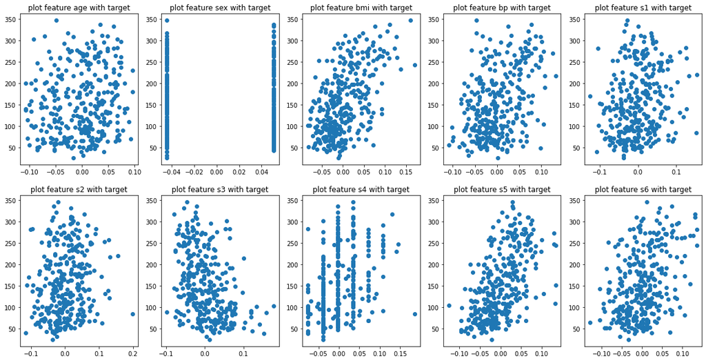

```python
plt.figure(figsize=(20, 10), facecolor="white")
for i, f in enumerate(diabetes.feature_names):
    plt.subplot(2, 5, i+1)
    plt.scatter(X_train[f], y_train)
    plt.title(f"plot feature {f} with target")
```

```python
from sklearn.model_selection import cross_val_score
clf_reg = tree.DecisionTreeRegressor()
clf_total = clf_reg.fit(X_train, y_train)
cross_val_score(clf_reg, X_train, y_train, cv=10)
```

[output not shown]

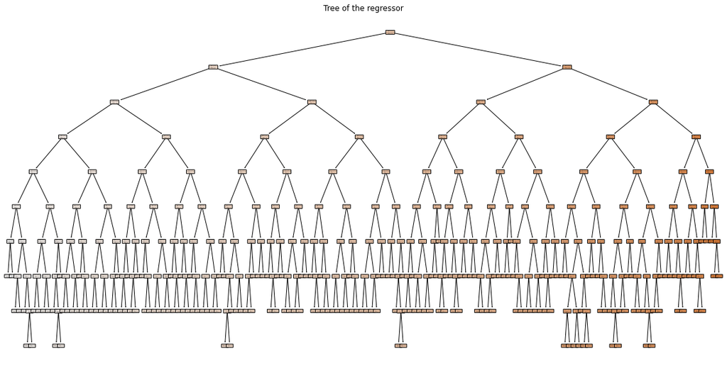

```python
plt.figure(figsize=(20, 10), facecolor="white")
tree.plot_tree(clf_reg,
                feature_names=X_train.columns,
                filled=True, rounded=True)
plt.title("Tree of the regressor")
plt.show()
```

We can see that the tree grew deeper very quickly in order to get to "pure" leaves, this can lead to memory problem. So we should either consider changing the values of the hyperparameters like min_samples_leaf or the max_depth; or make use of the random forest models as they consider a part of the data and only some of the features (we can set these parameters in RF as well)

## Step 4: Random forests

Go to

http://scikit-learn.org/stable/modules/generated/sklearn.ensemble.RandomForestClassifier.html

for a documentation about the `RandomForestClassifier` provided by `scikit-learn`.

Since target values must be integers, we first need to transform labels into numbers as below.

```python
# train['species'] contains the actual species names. Before we can use it,
# we need to convert each species name into a digit. So, in this case there
# are three species, which have been coded as 0, 1, or 2.
y = pd.factorize(train['species'])[0]

# View target
y
```

```
array([0, 0, 0, 0, 0, 0, 0, 0, 0, 0, 0, 0, 0, 0, 0, 0, 0, 0, 0, 0, 0, 0,
       0, 0, 0, 0, 0, 0, 0, 0, 0, 0, 0, 0, 0, 0, 0, 0, 0, 0, 0, 0, 0, 1,
       1, 1, 1, 1, 1, 1, 1, 1, 1, 1, 1, 1, 1, 1, 1, 1, 1, 1, 1, 1, 1, 1,
       1, 1, 1, 1, 1, 1, 1, 1, 1, 1, 1, 2, 2, 2, 2, 2, 2, 2, 2, 2, 2, 2,
       2, 2, 2, 2, 2, 2, 2, 2, 2, 2, 2, 2, 2, 2, 2, 2, 2, 2, 2, 2, 2, 2,
       2, 2, 2, 2, 2], dtype=int64)
```

```python
# Create a random forest Classifier. By convention, clf means 'Classifier'
rf = RandomForestClassifier(n_jobs=2, random_state=0)

# Train the Classifier to take the training features and learn how they relate
# to the training y (the species)
rf.fit(train[features], y)
```

```
RandomForestClassifier(n_jobs=2, random_state=0)
```

**Make predictions** and create actual english names for the plants for each predicted plant class:

```python
preds = rf.predict(test[features])
preds_names = pd.Categorical.from_codes(preds, iris.target_names)
preds_names
```

```
['setosa', 'setosa', 'setosa', 'setosa', 'setosa', ..., 'virginica', 'virginica', 'virginica', 'virginica', 'virginica']
Length: 35
Categories (3, object): ['setosa', 'versicolor', 'virginica']
```

### Create a confusion matrix

```python
# Create confusion matrix unsing pandas:
pd.crosstab(test['species'], preds, rownames=['Actual Species'], colnames=['Predicted Species'])
```

| Predicted Species Actual Species | 0 | 1 | 2 |
| --- | --- | --- | --- |
| setosa | 7 | 0 | 0 |
| versicolor | 0 | 16 | 0 |
| virginica | 0 | 0 | 12 |

## Feature selection using random forests byproducts

One of the interesting use cases for random forest is feature selection. One of the byproducts of trying lots of decision tree variations is that you can examine which variables are working best/worst in each tree.

When a certain tree uses one variable and another doesn't, you can compare the value lost or gained from the inclusion/exclusion of that variable. The good random forest implementations are going to do that for you, so all you need to do is know which method or variable to look at.

### View feature importance

While we don't get regression coefficients like with ordinary least squares (OLS), we do get a score telling us how important each feature was in classifying. This is one of the most powerful parts of random forests, because we can clearly see that petal width was more important in classification than sepal width.

```python
# View a list of the features and their importance scores
list(zip(train[features], rf.feature_importances_))
```

```
[('sepal length (cm)', 0.1054477764182299),
 ('sepal width (cm)', 0.023864868627945412),
 ('petal length (cm)', 0.4518587296296779),
 ('petal width (cm)', 0.41882862532414683)]
```

## Exercise 3

1. Comment on the feature importances with respect to your previous observations on decision trees above.
2. Extract and visualize 5 trees belonging to the random forest using the attribute `estimators_` of the trained random forest classifier. Compare them. *Note that you may code a loop on extracted trees.*
3. Study the influence of parameters like `max_depth`, `min_samples_leaf` and `min_samples_split`. Try to optimize them and explain your approach and choices.
4. How is estimated the prediction error of a random forest ? *Indication: have a look at parameter `oob_score`.* What are out-of-bag samples ?
5. What should you do when classes are not balanced in the dataset ? (that is when there are much more examples of one class than another)
1. The importance scores confirms well our previous results. Petal features have a similar importance and as we saw they are enough to well classify. Sepal width is the least important feature (and uncorrelated with the other features)

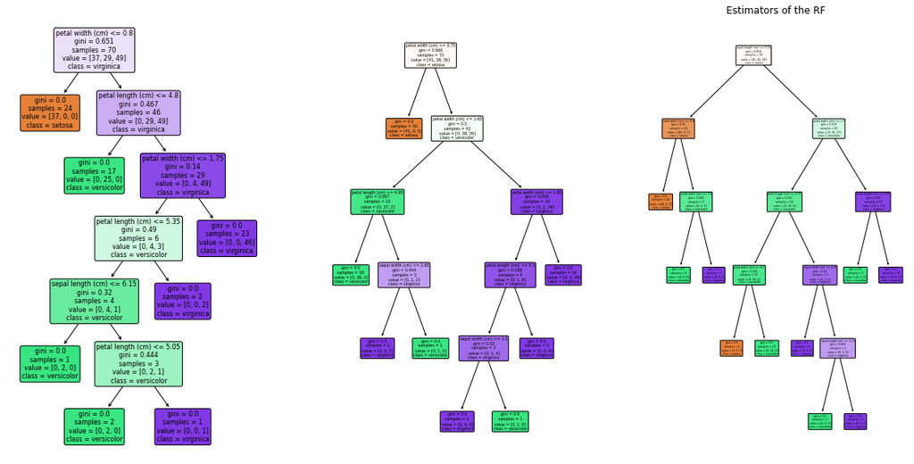

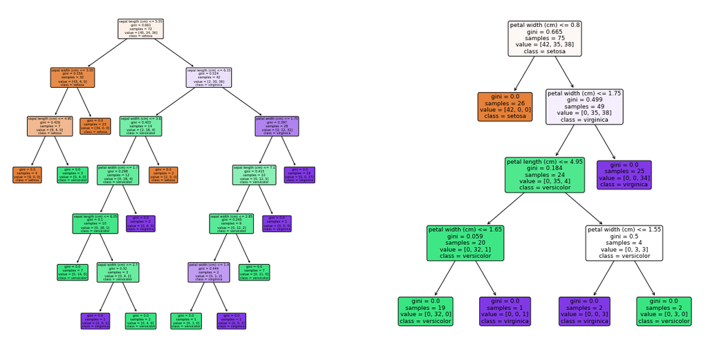

```python
trees=[]
plt.figure(figsize=(20, 10), facecolor="white")
for i in range (3) :
    plt.subplot(1, 3, i+1)
    tree.plot_tree(rf.estimators_[i],
                    feature_names=iris.feature_names,
                    class_names=iris.target_names,
                    filled=True, rounded=True)
plt.title("Estimators of the RF")
plt.show()
plt.figure(figsize=(20, 10), facecolor="white")
for i in [3, 4] :
    plt.subplot(1, 2, i-2)
    tree.plot_tree(rf.estimators_[i],
                    feature_names=iris.feature_names,
                    class_names=iris.target_names,
                    filled=True, rounded=True)
plt.show()
```

Some estimators are using only the petal features and they are the smallest (the last one for instance), others (like the second fourth one) combine the features and go deeper in order to reach pure nodes.

##### The influence of parameters like max_depth, min_samples_leaf and min_samples_split

To see the influence of the parameters, we do a gridsearch on these parameters.

It is an optimization method that will allow us to test a series of parameters and compare performance to deduce the best setting.

We optimized the parameters separately because when we try to optimize the 3 parameters together, it takes a lot of time.

##### max_depth

```python
from sklearn.model_selection import GridSearchCV

max_depth_list = [i for i in range(1, 20)]
params = {"max_depth": max_depth_list}

clf_finetuned = tree.DecisionTreeClassifier()
clf_cv = GridSearchCV(clf_finetuned, params)
clf_cv.fit(train[features], y)
print(f"the optimal max depth = {clf_cv.best_params_['max_depth']}")
```

```
the optimal max depth = 5
```

##### min_samples_leaf

```python
min_samples_leaf_list = [i for i in range(1, 60)]
params = {"min_samples_leaf": min_samples_leaf_list}
clf_finetuned = tree.DecisionTreeClassifier()
clf_cv = GridSearchCV(clf_finetuned, params)
clf_cv.fit(train[features], y)
print(f"the optimal min_samples_leaf = {clf_cv.best_params_['min_samples_leaf']}")
```

```
the optimal min_samples_leaf = 1
```

##### min_samples_split

```python
min_samples_split_list = [i for i in range(2, 100)]
params = {"min_samples_split": min_samples_split_list}
clf_finetuned = tree.DecisionTreeClassifier()
clf_cv = GridSearchCV(clf_finetuned, params)
clf_cv.fit(train[features], y)
print(f"the optimal min_samples_split = {clf_cv.best_params_['min_samples_split']}")
```

```
the optimal min_samples_split = 2
```

##### The 3 parameters

```python
max_depth_list = [i for i in range(1, 20)]
min_samples_leaf_list = [i for i in range(1, 20)]
min_samples_split_list = [i for i in range(2, 20)]

params = {"max_depth": max_depth_list, "min_samples_leaf": min_samples_leaf_list, "min_samples_split": min_samples_split_list}
clf_finetuned = tree.DecisionTreeClassifier()
clf_cv = GridSearchCV(clf_finetuned, params)
clf_cv.fit(train[features], y)
print(f"the optimal max depth = {clf_cv.best_params_['max_depth']}, the optimal min_samples_leaf = {clf_cv.best_params_['min_samples_leaf']} and the optimal min_samples_split = {clf_cv.best_params_['min_samples_split']}")
```

```
the optimal max depth = 3, the optimal min_samples_leaf = 5 and the optimal min_samples_split = 2
```

```python
clf_optimal = tree.DecisionTreeClassifier(max_depth=clf_cv.best_params_['max_depth'],
                                          min_samples_leaf=clf_cv.best_params_['min_samples_leaf'],
                                          min_samples_split=clf_cv.best_params_['min_samples_split'])
clf_optimal.fit(train[features], y)
y_pred = clf_optimal.predict(test[features])

print("Accuracy:", accuracy_score(y_test, y_pred))
```

```
Accuracy: 0.9428571428571428
```

##### How is estimated the prediction error of a random forest ?

```python
# Create a random forest Classifier. By convention, clf means 'Classifier'
rf = RandomForestClassifier(n_jobs=2, random_state=0, oob_score=True)

# Train the Classifier to take the training features and learn how they relate
# to the training y (the species)
rf.fit(train[features], y)
```

```
RandomForestClassifier(n_jobs=2, oob_score=True, random_state=0)
```

```python
oob_error = 1 - rf.oob_score_
print(f"The oob_error = {oob_error}")
```

```
The oob_error = 0.05217391304347829
```

The oob error is quite small so our model classifies well the data.

##### What should you do when classes are not balanced in the dataset ?

- Try to increase the data of the sample of the minority class with data augmentation
- When boosting, try to choose samples from the classes fairly

## Step 5: a small example of regression using random forests

Random forest is capable of learning without carefully crafted data transformations. Take the the $f(x) = \sin(x)$ function for example.

Create some fake data and add a little noise.

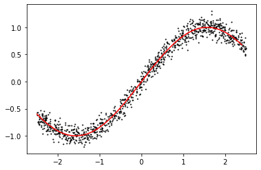

```python
x = np.random.uniform(-2.5, 2.5, 1000)
y = np.sin(x) + np.random.normal(0, .1, 1000)

plt.plot(x,y,'ko',markersize=1,label='data')
plt.plot(np.arange(-2.5,2.5,0.1),np.sin(np.arange(-2.5,2.5,0.1)),'r-',label='ref')
plt.show()
```

If we try and build a basic linear model to predict y using x we end up with a straight line that sort of bisects the sin(x) function. Whereas if we use a random forest, it does a much better job of approximating the sin(x) curve and we get something that looks much more like the true function.

Based on this example, we will illustrate how the random forest isn't bound by linear constraints.

## Exercise 4

1. Apply random forests on this dataset for regression and compare performances with ordinary least squares regression. *Note that ordinay least square regression is available thanks to: from sklearn.linear_model import LinearRegression*
2. Comment on your results.

```python
x_train, x_test, y_train, y_test = train_test_split(x.reshape(-1, 1), y, test_size=0.2)
```

[output not shown]

```python
from sklearn.linear_model import LinearRegression
from sklearn.ensemble import RandomForestRegressor
linear_reg = LinearRegression()
rf_reg = RandomForestRegressor()
```

```python
rf_reg.fit(x_train, y_train)
linear_reg.fit(x_train, y_train)
```

```
LinearRegression()
```

```python
print("score of the random forest regressor on the test set:", round(rf_reg.score(x_test, y_test), 4))
print("score of the least square regressor on the test set:", round(linear_reg.score(x_test, y_test), 4))
```

```
score of the random forest regressor on the test set: 0.9797
score of the least square regressor on the test set: 0.8719
```

We can see that the linear regression (on the data itself and not a different representation of it) doesn't perform really well, compared to the random forest model that we have yet to finetune. It was to expected that the former doesn't work well as the predition is a linear function of the data whereas we are trying to predicted sin function. We next plot the predictions of both models:

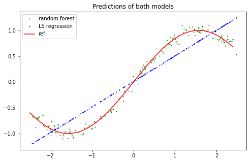

```python
pred_rf = rf_reg.predict(x_test)
pred_lr = linear_reg.predict(x_test)
plt.figure(figsize=(8, 5), facecolor="white")
plt.plot(x_test, pred_rf, 'o', markersize=1, label='random forest', color="green")
plt.plot(x_test, pred_lr, 'o', markersize=1, label='LS regression', color="blue")
plt.plot(np.arange(-2.5,2.5,0.1),np.sin(np.arange(-2.5,2.5,0.1)),'r-',label='ref')
plt.legend()
plt.title("Predictions of both models")
plt.show()
```

The random forest fits well to the data, even when the model was not linear, which confirms what we concluded in the previous step. We have seen that the Random Forest can estimate the function that we want to predict (and the deeper trees the better the estimation), so we will plot the predicted function and we will tackle this hyperparameter in the finetuning section:

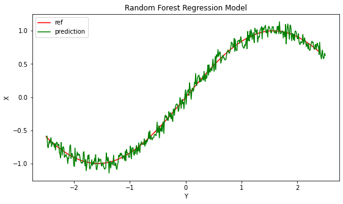

```python
plt.figure(figsize=(9, 5), facecolor="white")
X_grid = np.arange(min(x_train), max(x_train), 0.01)
X_grid = X_grid.reshape((len(X_grid), 1))
# plt.plot(x_test, y_test, 'o', color = 'black')
plt.plot(np.arange(-2.5,2.5,0.1),np.sin(np.arange(-2.5,2.5,0.1)),'r-',label='ref')
plt.plot(X_grid, rf_reg.predict(X_grid), color = 'green', label="prediction")
plt.title('Random Forest Regression Model')
plt.xlabel('Y')
plt.ylabel('X')
plt.legend()
plt.show()
```

The model has a good global estimation of the function but it fluctuates a lot so we might be overfitting (high variance), in the next part we will try to find the best parameters for our regressor:

### FineTuning the model

Here we will finetune the random forest regressor on parameters we have not talked about yet: n_estimators, max_depth, ccriterions and ccp_alpha where we evaluate the complexity (it ranges bewteen 0 and 0.35 as per the keras documentation). The poisson criterion doesn't allow negative values, so it won't be visited.

```python
from sklearn.model_selection import GridSearchCV

params = {"n_estimators": [10, 30, 50, 100]}
rf_finetuned = RandomForestRegressor()
gridcv = GridSearchCV(rf_finetuned, params, cv=10)
gridcv.fit(x_train, y_train)
gridcv.best_params_
```

```
{'n_estimators': 50}
```

```python
params = {"criterion":["squared_error", "absolute_error"]}
rf_finetuned = RandomForestRegressor(n_estimators=100)
gridcv = GridSearchCV(rf_finetuned, params, cv=10)
gridcv.fit(x_train, y_train)
gridcv.best_params_
```

```
{'criterion': 'absolute_error'}
```

```python
params = {"ccp_alpha": np.linspace(0, 0.5, 10)}
rf_finetuned = RandomForestRegressor(n_estimators=100, criterion="absolute_error")
gridcv = GridSearchCV(rf_finetuned, params, cv=10)
gridcv.fit(x_train, y_train)
```

```
GridSearchCV(cv=10, estimator=RandomForestRegressor(criterion='absolute_error'),
             param_grid={'ccp_alpha': array([0.        , 0.05555556, 0.11111111, 0.16666667, 0.22222222,
       0.27777778, 0.33333333, 0.38888889, 0.44444444, 0.5       ])})
```

```python
gridcv.best_params_
```

```
{'ccp_alpha': 0.0}
```

```python
params = {"max_depth": [5, 10, 20, 50]}
rf_finetuned = RandomForestRegressor(n_estimators=100, criterion="absolute_error")
gridcv = GridSearchCV(rf_finetuned, params, cv=10)
gridcv.fit(x_train, y_train)
gridcv.best_params_
```

```
{'max_depth': 5}
```

Our best estimator has a maximum depth of only 5, which confirms the assumption that we were overfitting. Reducing the max_depth to 5 will result in less fluctuations as we will later:

```python
best_finetuned = gridcv.best_estimator_
```

Now that we have our finetuned model, we can plot the new predicted function and compare it to our ground truth:

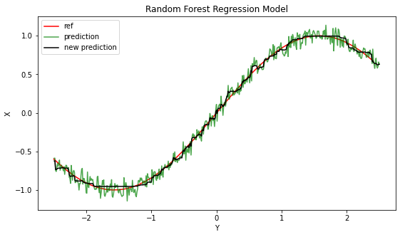

```python
plt.figure(figsize=(9, 5), facecolor="white")
X_grid = np.arange(min(x_train), max(x_train), 0.01)
X_grid = X_grid.reshape((len(X_grid), 1))
# plt.plot(x_test, y_test, 'o', color = 'black')
plt.plot(np.arange(-2.5,2.5,0.1),np.sin(np.arange(-2.5,2.5,0.1)),'r-',label='ref')
plt.plot(X_grid, rf_reg.predict(X_grid), alpha=.7, color = 'green', label="prediction")
plt.plot(X_grid, best_finetuned.predict(X_grid), color = 'black', label="new prediction")

plt.title('Random Forest Regression Model')
plt.xlabel('Y')
plt.ylabel('X')
plt.legend()
plt.show()
```

### Indications:

You may use half of points for training and others to test predictions. Then you will have an idea of how far the random forest predictor fits the sinus curve.

To this aim, you will need to use the model `RandomForestRegressor`. Be careful that when only 1 feature `x` is used as an input, you will need to reshape it by `x.reshape(-1,1)` when using methods `fit` and `predict`.

```python
regrf = RandomForestRegressor(n_estimators=30, max_depth=4)
regrf.fit(x[0::2].reshape(-1, 1),y[0::2])
```

```
RandomForestRegressor(max_depth=4, n_estimators=30)
```

```python
from sklearn.linear_model import LinearRegression
...
```

### Indication

One clever way to compare models when using `scikit-learn`is to make a loop on models as follows:

```python
models = [DecisionTreeClassifier(max_depth=None),
          RandomForestClassifier(n_estimators=n_estimators)]

for model in models:
    ...
```

[output not shown]

## Documentation

### Decision trees

http://scikit-learn.org/stable/modules/tree.html

### Random forests

http://scikit-learn.org/stable/modules/generated/sklearn.ensemble.RandomForestClassifier.html

### Plot decision surface : using `plt.contourf`

http://scikit-learn.org/stable/auto_examples/tree/plot_iris.html#sphx-glr-auto-examples-tree-plot-iris-py

## Pruning trees: not available in scikit-learn.

Since post-pruning of tree is not implemented in scikit-learn, you may think of coding your own pruning function. For instance, taking into account the numer of samples per leaf as proposed below:

```python
# Pruning function (useful ?)
def prune(decisiontree, min_samples_leaf = 1):
    if decisiontree.min_samples_leaf >= min_samples_leaf:
        raise Exception('Tree already more pruned')
    else:
        decisiontree.min_samples_leaf = min_samples_leaf
        tree = decisiontree.tree_
        for i in range(tree.node_count):
            n_samples = tree.n_node_samples[i]
            if n_samples <= min_samples_leaf:
                tree.children_left[i]=-1
                tree.children_right[i]=-1
```